# Text and sentiment analysis

This post shows the results from a text analysis and sentiment analysis of The Handmaid’s Tail by Margaret Atwood

Nicole Schmidt true  
03-09-2021

```r
knitr::opts_chunk$set(echo = TRUE)

library(tidyverse)
library(tidytext)
library(textdata)
library(pdftools)
library(ggwordcloud)
library(png) #import images
library(ggpubr) # add images to ggplot
library(patchwork)
```

#### Introduction

The Handmaid’s Tail, by Margaret Atwood, is a popular dystopian novel about a Christian fundamentalist theocratic regime that takes power over the United States in response to a fertility crisis. This project undergoes a text and sentiment analysis to understand the most commonly used words and emotional trends throughout the novel. The first section looks at the most common words by chapter, and the top 50 most common words used throughout the novel. The second part is a sentiment analysis looking at the emotional trend.

```r
#Read in The Handmaid's Tail

handmaids_tail_text <- pdf_text("handmaidstale_margaret_atwood.pdf")

#handmaids_tail_p34 <- handmaids_tail_text[34]
#handmaids_tail_p34

#Get text into data frame and tidy format:
#each line has its own row
#get rid of extra white space

handmaids_tail_tidy <- data.frame(handmaids_tail_text) %>% # each line is a page
  mutate(text_full = str_split(handmaids_tail_text, pattern = '\\n')) %>%  # string split recognizes where there is a line break and splits it up; each line from each page is an element of a vector
  unnest(text_full) %>%  # gives each line its own row; each element in each vector has its own space
  mutate(text_full = str_trim(text_full)) # cleans up white space
```

#### Part 1: Text Analysis

```r
# More tidying

handsmaid_df <- handmaids_tail_tidy %>%
  slice(-(1:16)) %>%  # remove rows until chapter one begins
  mutate(chapter = case_when(
    str_detect(text_full, pattern = "CHAPTER") ~ text_full,
    TRUE ~ NA_character_)) %>%   # use string detect to detect the word chapter
  fill(chapter) %>%
  separate(col = chapter, into = c("ch", "no"), sep = " ") %>%
  mutate(chapter = as.numeric(no)) # makes chapter column numeric

# Tidy to get a column that has lines separated by words
handmaids_tokens <- handsmaid_df %>%
  unnest_tokens(word, text_full) %>%  # each word is its own line
  select(-handmaids_tail_text) # get ris of this column

# word count by chapter and remove stop words
handmaids_ch_wordcount <- handmaids_tokens %>%
  anti_join(stop_words) %>%  # removes stop words
  count(chapter, word)
```

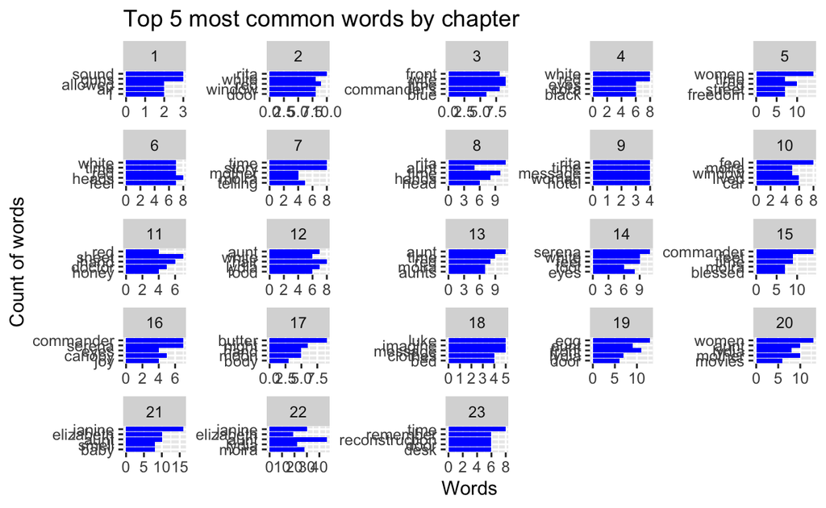

```r
# Word count by chapter for first half of book
top_5_words_23 <- handmaids_ch_wordcount %>%
  filter(chapter %in% c(1:23)) %>%
  group_by(chapter) %>%
  arrange(-n) %>%
  slice(1:5)

# graph
ggplot(data = top_5_words_23, aes (y = fct_reorder(word, n), x = n))+
  geom_col(fill = "blue")+
  facet_wrap(~chapter, scales = "free")+
  labs(title = "Top 5 most common words by chapter", x = "Words", y = "Count of words")
```

**Figure 1:** The top 5 most common words by chapter of the first half of The Handmaid’s Tail by Margaret Atwood.

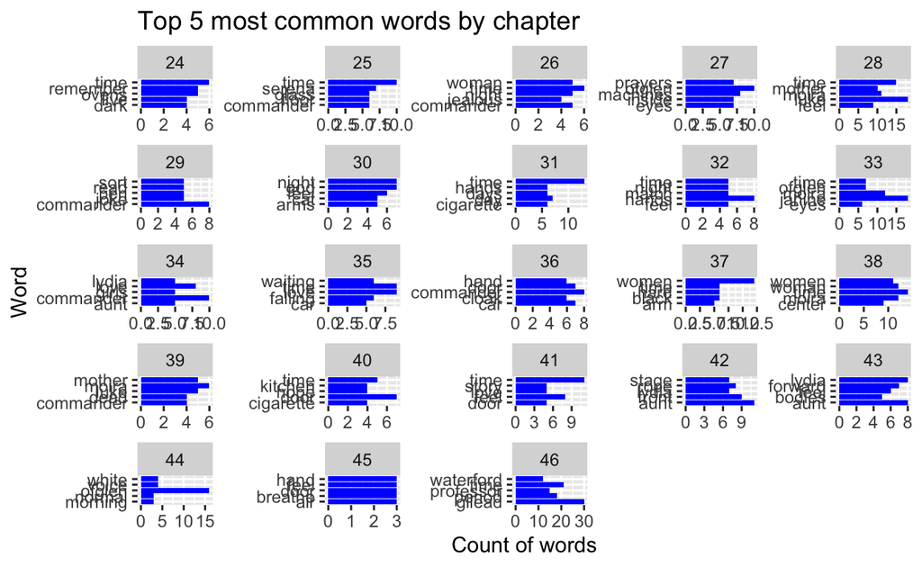

```r
# Word county by chapter for second half of book
top_5_words_46 <- handmaids_ch_wordcount %>%
  filter(chapter %in% c(24:46)) %>%
  group_by(chapter) %>%
  arrange(-n) %>%
  slice(1:5)

# graph
ggplot(data = top_5_words_46, aes (x = word, y = n))+
  geom_col(fill = "blue")+
  facet_wrap(~chapter, scales = "free")+
  coord_flip()+
  labs(title = "Top 5 most common words by chapter", x = "Word", y = "Count of words")
```

**Figure 2:** The top 5 most common words by chapter of the second half of The Handmaid’s Tail by Margaret Atwood.

[figure not shown]

```r
# import image for background of word cloud
img <- readPNG("handmaid1.png")

### make a word cloud of top 50 most used words in the novel

#tidy for word count of entire novel
handmaids_nonstop <- handmaids_tokens %>%
  anti_join(stop_words)

# get top 50 and filter out character names
top_50 <- handmaids_nonstop  %>%
  count(word) %>%
   filter(!word %in% c("janine", "moira", "lydia", "elizabeth", "luke", "ofglen", "waterford", "rita", "serena", "cora")) %>%
  arrange(-n) %>%
  slice(1:50)

# create the word cloud
cloud <- ggplot(data = top_50, aes(label = word))+
  background_image(img)+
  geom_text_wordcloud(aes(color = n, size = n), shape = "triangle-forward")+
  scale_size_area(max_size = 10)+
 scale_color_gradientn(colors = c("gray68", "gray26", "gray8"))+
  theme_minimal()


cloud
```

#### Part 2: Sentiment Analysis

```r
#get_sentiments(lexicon = "afinn")

# first bind words in from the handmaids tail nonstop to afinn

handmaid_afinn <- handmaids_nonstop %>%
  inner_join(get_sentiments("afinn"))

# get counts by sentiment ranking
afinn_counts <- handmaid_afinn %>%
  count(chapter, value)

# get mean afinn score by chapter:
afinn_mean <- handmaid_afinn %>%
  group_by(chapter) %>%
  summarize(mean_afinn = mean(value))

#Plot
graph_a <- ggplot(data = afinn_mean,
       aes(x = fct_rev(as.factor(chapter)),
           y= mean_afinn))+
  geom_col(fill = "midnightblue")+
  coord_flip()+
  labs( x = "Chapter", y = "Afinn value", title = "Sentiment values by chapter")
```

```r
handmaids_nrc <- handmaids_nonstop %>%
  inner_join(get_sentiments("nrc"))

# find the top nrc bins by sentiment

top_nrc <- handmaids_nrc %>%
  count(sentiment) %>%
  arrange(-n)

graph_b <- ggplot(data = top_nrc, aes (y = n, x = fct_reorder(sentiment, n)))+
  geom_col(fill = "midnightblue")+
  coord_flip()+
  labs(title = "NRC sentiment values", x = "NRC Sentiment", y = "Count of NRC sentiment")+
  theme_classic()
```

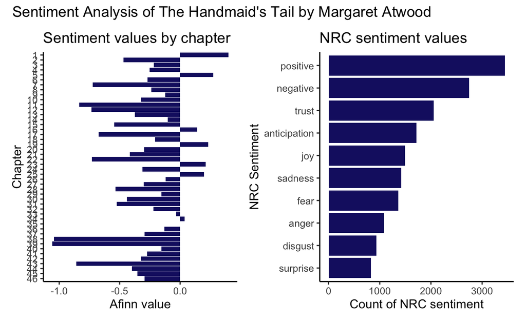

```r
#get plots together into one plot

graph_c <- (graph_a | graph_b) & theme_classic() &
  plot_annotation(title = "Sentiment Analysis of The Handmaid's Tail by Margaret Atwood")

graph_c
```

**Figure 3:** Displays the Sentiment analysis for The Handmaid’s Tail by Margaret Atwood. The left graph shows the mean Afinn sentiment value by chapter. The right graph shows the top NRC sentiment values throughout the entire novel. Although most of the chapters have a negative sentiment value, the most common NRC sentiment is associated with “positive”. Many negative NRC bins are displayed, such as negative, sadness, fear, anger, disgust, and surprise. It is no surprise that The Handmaid’s Tail, which is a dystopian novel, is largely associated with negative sentiments.

#### Sources

- Atwood, M. (1998). *The handmaid’s tale* (1st Anchor Books ed.). Anchor Books.
- Crowd sourcing a Word-Emotion Association Lexicon, Saif Mohammad and Peter Turney, Computational Intelligence, 29 (3), 436-465, 2013.
- Josh D. Jackson, Image retrieved from: https://www.pastemagazine.com/books/the-handmaid-s-tale/novels-read-after-handmaids-tale-margaret-atwood/